# Analysis of Different Predictive Models for Prediction of Aromatic Rings in SRC Kinase Inhibitors

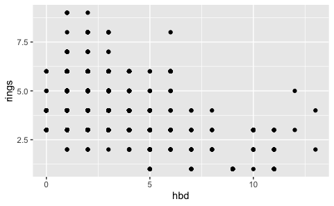

```r
ggplot(data = src_kin_2) +
  geom_point(mapping = aes(x = hbd, y = rings))
```

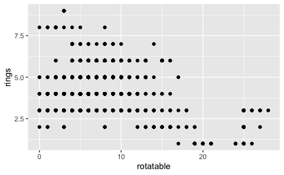

```r
ggplot(data = src_kin_2) +
  geom_point(mapping = aes(x = rotatable, y = rings))
```

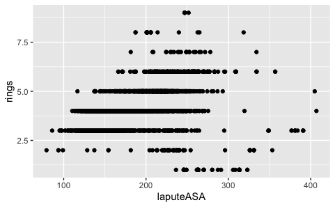

```r
ggplot(data = src_kin_2) +
  geom_point(mapping = aes(x = laputeASA, y = rings))
```

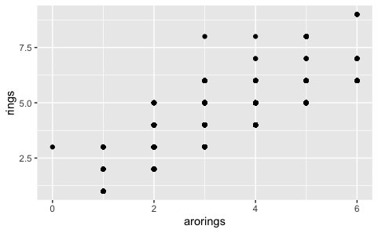

```r
ggplot(data = src_kin_2) +
  geom_point(mapping = aes(x = arorings, y = rings))
```

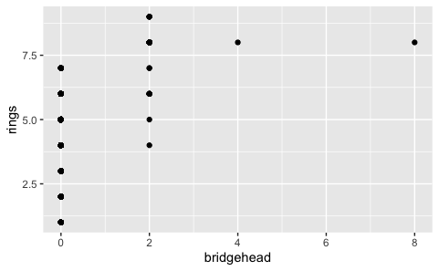

```r
ggplot(data = src_kin_2) +
  geom_point(mapping = aes(x = bridgehead, y = rings))
```

```r
NA
NA
NA
```

#### Correlation Plot of Covariates

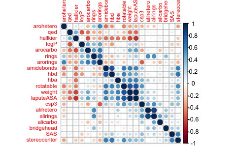

```r
# We also want to analyze the collinearity or correlation between certain variables, so we create a correlation plot to see which are highly correlated and which variables are not
library(corrplot)
corMatMy <- cor(src_kin_2[,1:20])
corrplot(corMatMy, order = "hclust", tl.cex = 0.7)
```

#### Data Training and Testing Split

Now that we have completed the pre-processing and initial analysis of the variables, we move into creating training and testing sets of our data for the predictive models. The outcome variable we would like to predict is the “Rings” variable and the feature set is based on the other chemical attributes calculated.

This block of code divides the data set into training, validation, and testing. This was coded with help from stack overflow for debugging questions, but the main base of it is that we split up the training as 60% of the data, and the testing as 40% of the data. Training and testing help in making sure the model can predict accurately for the predictor variable given the data set features. We first start off by defining variables that contain the percentages of our training and testing data. We then define the indices while also randomizing our sample set for each divide. Lastly using the indices calculated, we create a training data frame and testing data frame.

```r
# Now that we have completed the pre-processing and initial analysis of the variables, we move into creating training and testing sets of our data for the predictive models. The outcome variable we would like to predict is the "Rings" variable and the feature set is based on the other chemical attributes calculated.

# this block of code divides the dataset into training, validation, and testing. This was coded with help from stack overflow for debugging questions, but the main base of it is that we split up the training as 60% of the data, the validation as 20% of the data and the testing as 20% of the data. Training, validation and testing help in making sure the model can predict accurately for the predictor variable given the dataset features. We first start off by defining variables that contain the percentages of our training, validation and testing data. We then define the indices while also randomizing our sample set for each divide. Lastly using the indices calculated, we create a training dataframe, validation dataframe, and testing dataframe.

df <- src_kin_2
trperc=0.6
testperc=0.4

percTraining <- trperc
percTesting <- testperc

samplesizeTraining <- floor(percTraining * nrow(df))
samplesizeTesting <- floor(percTesting * nrow(df))

trainingind <- sort(sample(seq_len(nrow(df)), size = samplesizeTraining))
nottrainingind <- setdiff(seq_len(nrow(df)), trainingind)
testingind <- sort(sample(nottrainingind, size=samplesizeTesting))

training_df <- df[trainingind, ]
testing_df <- df[testingind, ]
```

### Model Building and Analysis

Now I will do some model building. Here we will analyze the performance of 4 models and determine the best fit model for the data:

- Linear Regression Model
- Log-Linear Model
- Random Forest Model
- Neural Network

The predictor variable is the number of rings and we have around 20 covariates that will be in the model.

#### Linear Regression Model

```r
# Now I will do some model building. Here we will analyze the performance of 4 models: Linear Regression Model, Log-Linear Model, Random Forest Model, and Neural Network. The predictor variable is the number of rings and we have around 20 covariates.

# Fit a linear regression model with the data. We want to analyze if the linear regression model will fit the data well or if it will give us an overfitted model.

install.packages("MASS")
```

```
Error in install.packages : Updating loaded packages
```

```r
library(MASS)

# fit the linear model to the data. rings=predictor variable
fit_src2.glm <- lm(rings~.,data=src_kin_2)

# run stepAIC to find the best linear regression model fit
fit_src2.step <- stepAIC(fit_src2.glm, trace = FALSE)
# get summary and plot
summary(fit_src2.step)
```

```
Call:
lm(formula = rings ~ qed + SAS + logP + weight + csp3 + hallkier +
    laputeASA + alicarbo + alihetero + alirings + amidebonds +
    arocarbo + arohetero + arorings + stereocenter + bridgehead +
    hba + hbd + rotatable, data = src_kin_2)

Residuals:
       Min         1Q     Median         3Q        Max
-5.640e-14 -1.700e-15 -6.800e-16  4.600e-16  1.823e-12

Coefficients: (2 not defined because of singularities)
               Estimate Std. Error    t value Pr(>|t|)
(Intercept)   6.810e-14  1.025e-14  6.642e+00 3.60e-11 ***
qed          -5.173e-14  9.899e-15 -5.226e+00 1.84e-07 ***
SAS          -3.756e-16  1.894e-15 -1.980e-01    0.843
logP          1.882e-16  6.819e-16  2.760e-01    0.783
weight       -2.420e-17  4.740e-17 -5.110e-01    0.610
csp3         -2.532e-15  9.983e-15 -2.540e-01    0.800
hallkier      8.241e-16  1.587e-15  5.190e-01    0.604
laputeASA     2.540e-17  1.360e-16  1.870e-01    0.852
alicarbo      1.000e+00  1.814e-15  5.514e+14  < 2e-16 ***
alihetero     1.000e+00  1.396e-15  7.164e+14  < 2e-16 ***
alirings             NA         NA         NA       NA
amidebonds    1.885e-15  1.222e-15  1.543e+00    0.123
arocarbo      1.000e+00  1.623e-15  6.161e+14  < 2e-16 ***
arohetero     1.000e+00  1.317e-15  7.593e+14  < 2e-16 ***
arorings             NA         NA         NA       NA
stereocenter -2.943e-17  9.185e-16 -3.200e-02    0.974
bridgehead    1.913e-15  2.493e-15  7.670e-01    0.443
hba           4.612e-17  6.122e-16  7.500e-02    0.940
hbd          -5.248e-16  6.772e-16 -7.750e-01    0.438
rotatable     5.250e-16  3.976e-16  1.320e+00    0.187
---
Signif. codes:  0 ‘***’ 0.001 ‘**’ 0.01 ‘*’ 0.05 ‘.’ 0.1 ‘ ’ 1

Residual standard error: 3.17e-14 on 3349 degrees of freedom
Multiple R-squared:      1, Adjusted R-squared:      1
F-statistic: 2.091e+29 on 17 and 3349 DF,  p-value: < 2.2e-16
```

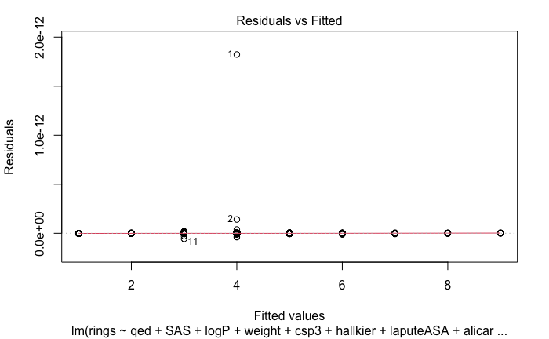

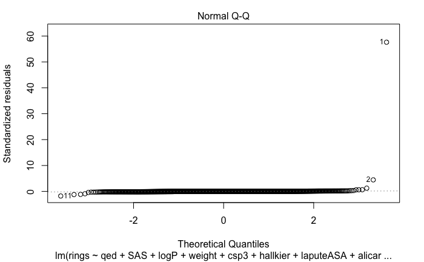

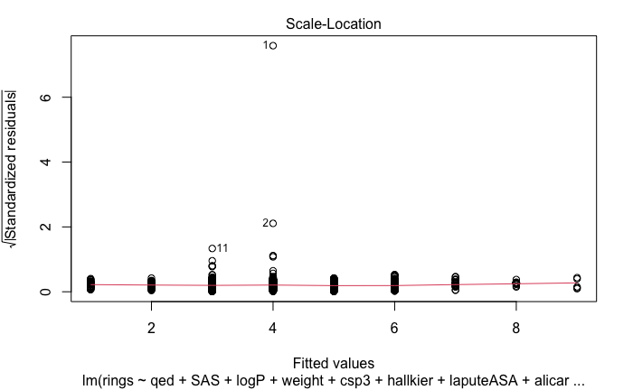

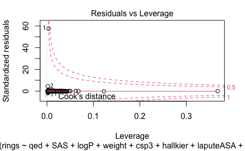

```r
plot(fit_src2.step)
```

##### Analysis of Linear Regression Model- Part 1

What we just achieved was building a basic linear regression model where we predicted the number of rings based on all of the co-variates we have in our data. By building the initial model, we see that we get an R2 of 1, which plays cause for concern. The fact that the R2 is 1 tells us immediately that the model is over-fitting the data. If we also take a look at the graphs:

1. The residual versus fitted graph has no even distribution of points across the red line which tells us that the model is not really accounting for the variance even though it is saying it is. You can also see that the points are clustered together in locations, which further advocates for the stated.
2. In the QQ plot, there is really no curve of the plotted line which shows indication of overfitting.
3. We see both clusters of residual points in the 3rd graph as well as clustering in the Cook’s Leverage graph. This can also be understood that, although our model tells us that it is accounting for 100% of the variance through our R2, we don’t see any graphical indication of a good model.

A key cause of this could be due to the amount of features in the model. There are significant features in the model such as alicarbo and alihetero, acting as main effects for the prediction, however, we see a good amount of features that are not playing a significant role. Therefore, we start off by implementing Backwards Elimination of variables to rid the model of insignificant variables and re-fit our linear model based on the values that are significant.

```r
#Now we implement Backwards elimination of features that do not provide significance to the model and we refit the data. Looking at the linear regression model fit, we can work to eliminate features that are not found as significant and see if those values change the outcome of the model.

# update the model and get rid of features that are insignificant to the model
fit_src3.glm <- update(fit_src2.glm, .~.-alirings)
fit_src3.glm <- update(fit_src3.glm, .~.-arorings)
fit_src3.glm <- update(fit_src3.glm, .~.-stereocenter)
fit_src3.glm <- update(fit_src3.glm, .~.-csp3)
fit_src3.glm <- update(fit_src3.glm, .~.-SAS)
fit_src3.glm <- update(fit_src3.glm, .~.-hallkier)
fit_src3.glm <- update(fit_src3.glm, .~.-amidebonds)
fit_src3.glm <- update(fit_src3.glm, .~.-hba)

# refit model to see if there is any change
fit_src3.step = stepAIC(fit_src3.glm,trace=FALSE)
# get summary and plot of results
summary(fit_src3.step)
```

```
Call:
lm(formula = rings ~ qed + logP + laputeASA + alicarbo + alihetero +
    arocarbo + arohetero + bridgehead + hbd + rotatable, data = src_kin_2)

Residuals:
       Min         1Q     Median         3Q        Max
-3.620e-14 -1.790e-15 -7.100e-16  4.200e-16  1.821e-12

Coefficients:
              Estimate Std. Error    t value Pr(>|t|)
(Intercept)  6.549e-14  8.938e-15  7.327e+00 2.92e-13 ***
qed         -4.562e-14  9.704e-15 -4.701e+00 2.69e-06 ***
logP        -1.432e-16  6.191e-16 -2.310e-01    0.817
laputeASA   -2.065e-17  3.440e-17 -6.000e-01    0.548
alicarbo     1.000e+00  1.611e-15  6.209e+14  < 2e-16 ***
alihetero    1.000e+00  1.155e-15  8.660e+14  < 2e-16 ***
arocarbo     1.000e+00  1.150e-15  8.699e+14  < 2e-16 ***
arohetero    1.000e+00  1.054e-15  9.490e+14  < 2e-16 ***
bridgehead   1.138e-15  2.234e-15  5.090e-01    0.611
hbd         -5.433e-16  5.254e-16 -1.034e+00    0.301
rotatable    4.688e-16  3.348e-16  1.400e+00    0.162
---
Signif. codes:  0 ‘***’ 0.001 ‘**’ 0.01 ‘*’ 0.05 ‘.’ 0.1 ‘ ’ 1

Residual standard error: 3.164e-14 on 3356 degrees of freedom
Multiple R-squared:      1, Adjusted R-squared:      1
F-statistic: 3.57e+29 on 10 and 3356 DF,  p-value: < 2.2e-16
```

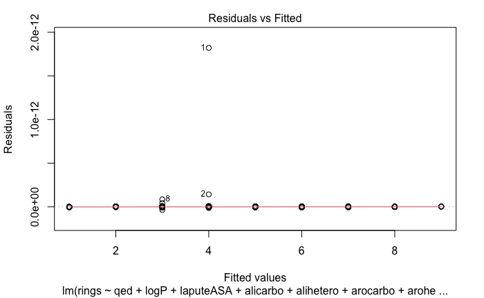

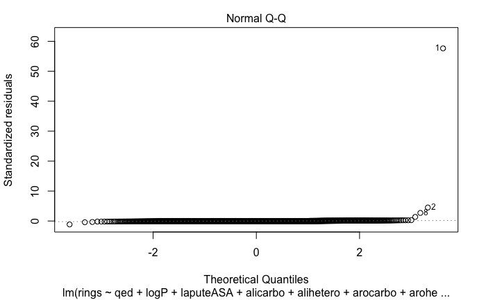

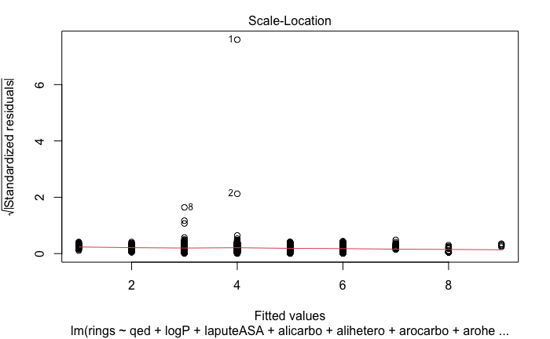

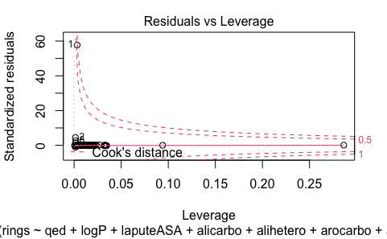

```r
plot(fit_src3.step)
```

##### Analysis of Linear Regression Model- Part 2

As you can see, even after eliminating unnecessary features and fitting with the features we found somewhat or highly significant, we still end up with a skewed model where there is still clustering of residual points, over-fitting shown by the R2 value and more. Therefore, we see that the Linear Regression Model is not the best fit model for the data and predictor variable, and we move on to the next model.

#### Log-Linear Model

Next, we will attempt to use a basic log-linear regression model to see whether it will fit better compared to a linear regression model.

Log-Linear models are used to model predictor variables that act as count variables, such as number of hospital beds over a certain month, etc.

```r
# In the linear regression model, we see that the data is still overfitting despite getting rid of insignificant variables and is causing issues in terms of prediction. From the graphical analysis and the output with an R2 of 1, we see that the model is not a good model for the prediction of aromatic rings.

# So, we attempt to use a basic log-linear regression model to see whether it will fit better compared to a linear regression model. The reason we chose log-linear is due to the fact the number of rings can also be considered as a count variable. When we try to fit a linear regression onto the model, we end up with a skewed and overfitted representation of the predicted data, so we try to interpret the outcome variable as a count variable to see whether it will give us a better predictive model compared to linear regression.

# fit a log-linear model to the data, rings=predictor variable
fit_src.glm = glm(rings~.,data=src_kin_2,family=poisson)

# use stepAIC to find the best log-linear model to fit the data
step_fit_src.glm = stepAIC(fit_src.glm,trace = FALSE)

# summary of results and plots of results
summary(step_fit_src.glm)
```

```
Call:
glm(formula = rings ~ alicarbo + alihetero + amidebonds + arocarbo +
    arohetero + stereocenter + bridgehead, family = poisson,
    data = src_kin_2)

Deviance Residuals:
     Min        1Q    Median        3Q       Max
-0.61388  -0.02157   0.01522   0.04697   0.78347

Coefficients:
             Estimate Std. Error z value Pr(>|z|)
(Intercept)   0.44511    0.04481   9.933   <2e-16 ***
alicarbo      0.24622    0.02303  10.692   <2e-16 ***
alihetero     0.23079    0.01340  17.221   <2e-16 ***
amidebonds   -0.01660    0.01131  -1.468   0.1420
arocarbo      0.23443    0.01220  19.211   <2e-16 ***
arohetero     0.23235    0.01442  16.111   <2e-16 ***
stereocenter -0.01871    0.01074  -1.742   0.0816 .
bridgehead   -0.05441    0.03022  -1.800   0.0718 .
---
Signif. codes:  0 ‘***’ 0.001 ‘**’ 0.01 ‘*’ 0.05 ‘.’ 0.1 ‘ ’ 1

(Dispersion parameter for poisson family taken to be 1)

    Null deviance: 871.608  on 3366  degrees of freedom
Residual deviance:  31.286  on 3359  degrees of freedom
AIC: 11083

Number of Fisher Scoring iterations: 4
```

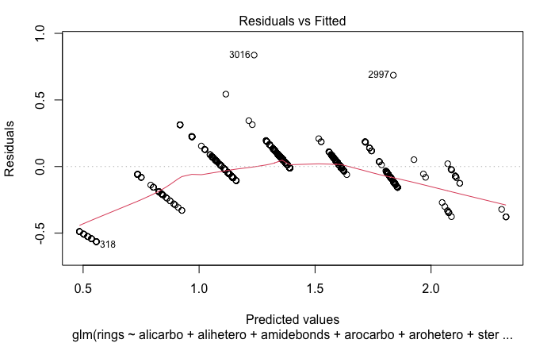

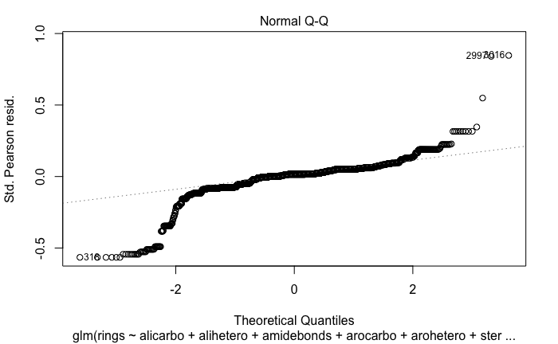

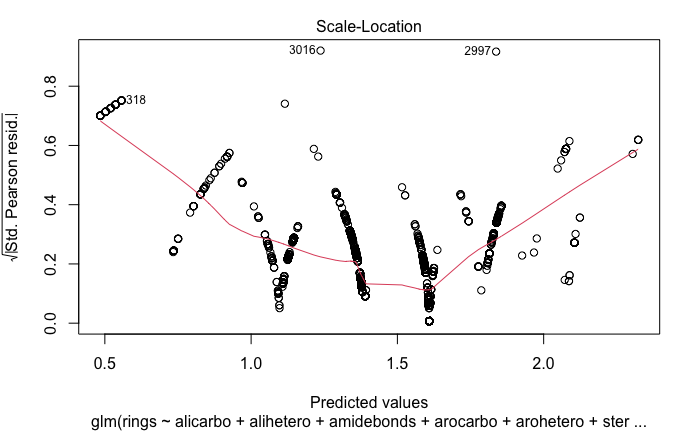

```r
plot(step_fit_src.glm)
```

[figure not shown]

```r
NA
```

##### Analysis of Log-Linear Regression Model

As we can see by the results of the log-linear regression model, we ultimately get a reasonable fit of the model to the data.

In this model too, we see that alicarbo, alihetero and some other co-variates that we saw in the last model prove to be very significant predictors and have important effects on the outcome variable.

The graphs show us that there is reasonable distribution of the residual points on the residuals versus fitted graph. We still see clustering of residual points however, which still indicates skewed model performance. We also see that there is even splittage of points below and above the red line of the residuals plot which portrays that this model is fitting somewhat reasonably. The QQ plot shows some skewage and deviation due to certain outliers of the data. The Cook’s Leverage plot also shows us some outliers which could be skewing the data and the model fit. When we look at the AIC however, it is very high, indicating poor performance of the model. Although interpreting the predictor variable as a count variable was helpful, it still did not lead us into finding a good enough model that fits the data well.

As shown above, the log-linear model does a better job of fitting the data and predicting the outcome variable, however, the model is still performing pretty horrible given the AIC value and the distributions of the residuals through the graphical analysis. Therefore, we move onto using a Random Forest model.

#### Random Forest Model

Now we move into higher techniques as we have determined that our predictor variable is more complex than we thought and we might need more complex models to account for the variance in the data. We attempt to fit a Random Forest model with certain parameters and see how well it is able to predict the ring count.

```r
# As shown above, the log-linear model does a better job of fitting the data and predicting the outcome variable, however, the model is still performing pretty horrible given the AIC value and the distributions of the residuals through the graphical analysis. Therefore, we move onto using a Random Forest model.

# Now let us try using Random Forest as a model for the data. This model might give us better results compared to the linear regression and log-linear models.

# we install the random forest package
install.packages("randomForest")
```

```r
# load the random forest library
library(randomForest)
# create training df that contains features and a predictor list that contains the prediction variable which in this case is rings
training_df_x <- subset(training_df,select=-rings)
training_y <- training_df$rings

# do the same as above but for testing
testing_df_x <- subset(testing_df,select=-rings)
testing_y <- testing_df$rings
```

```r
# get the summary of the random forest model.

# first random forest model predictions with trees = 15 and plot MSE for ntrees
rf_model <- randomForest(x=training_df_x, y=training_y, xtest=testing_df_x, ytest=testing_y, ntree=15)
summary(rf_model)
```

```
                Length Class  Mode
call               6   -none- call
type               1   -none- character
predicted       2020   -none- numeric
mse               15   -none- numeric
rsq               15   -none- numeric
oob.times       2020   -none- numeric
importance        19   -none- numeric
importanceSD       0   -none- NULL
localImportance    0   -none- NULL
proximity          0   -none- NULL
ntree              1   -none- numeric
mtry               1   -none- numeric
forest             0   -none- NULL
coefs              0   -none- NULL
y               2020   -none- numeric
test               4   -none- list
inbag              0   -none- NULL
```

```r
rf_model
```

```
Call:
 randomForest(x = training_df_x, y = training_y, xtest = testing_df_x,      ytest = testing_y, ntree = 15)
               Type of random forest: regression
                     Number of trees: 15
No. of variables tried at each split: 6

          Mean of squared residuals: 0.01565817
                    % Var explained: 98.54
                       Test set MSE: 0.02
                    % Var explained: 98.41
```

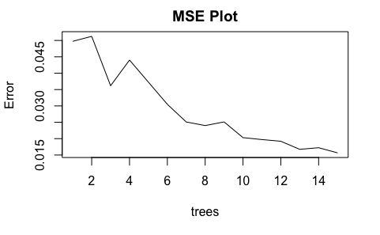

```r
plot(rf_model, type = 'l', main = "MSE Plot")
```

##### Random Forest Model 1 Analysis

We fit a Random Forest model to the data with an initial parameter value of 15 trees. As we can see through the output of our results, the Random Forest predicts very well with the mean of squared residuals being around 0.015 and the percentage of variance accounted for being around 98%. Also looking at the MSE graph, we see that the error significantly decreases as the number of trees increase. This gives us insight into how well the model predicts given the data and ultimately tells us that this model is ideal to predict the number of aromatic rings.

To see if we can improve the model a little more, we increase our tree count to 40 trees and see whether we can reduce the mean of squared residuals value.

```r
# second RF model with 40 trees and plot MSE over ntrees, this might improve the models accuracy and help it account for the variance in the model
rf_model <- randomForest(x=training_df_x, y=training_y, xtest=testing_df_x, ytest=testing_y, ntree=40)
summary(rf_model)
```

```
                Length Class  Mode
call               6   -none- call
type               1   -none- character
predicted       2020   -none- numeric
mse               40   -none- numeric
rsq               40   -none- numeric
oob.times       2020   -none- numeric
importance        19   -none- numeric
importanceSD       0   -none- NULL
localImportance    0   -none- NULL
proximity          0   -none- NULL
ntree              1   -none- numeric
mtry               1   -none- numeric
forest             0   -none- NULL
coefs              0   -none- NULL
y               2020   -none- numeric
test               4   -none- list
inbag              0   -none- NULL
```

```r
rf_model
```

```
Call:
 randomForest(x = training_df_x, y = training_y, xtest = testing_df_x,      ytest = testing_y, ntree = 40)
               Type of random forest: regression
                     Number of trees: 40
No. of variables tried at each split: 6

          Mean of squared residuals: 0.01189116
                    % Var explained: 98.89
                       Test set MSE: 0.02
                    % Var explained: 98.44
```

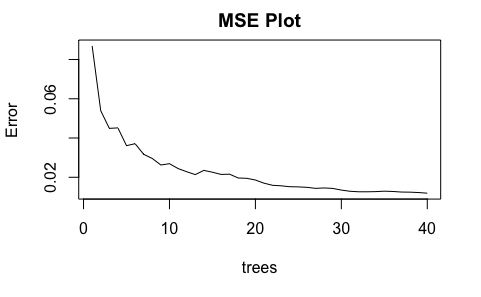

```r
plot(rf_model, type = 'l', main = "MSE Plot")
```

##### Random Forest Model 2 Analysis

As said before, the increase of the number of trees does improve the model slightly as it brings the mean of squared residuals value down to 0.011 and the test set MSE is 0.02. The % of Variance explained in training is 98.89% and the variance explained for testing is 98.44% indicating good performance. The MSE graph also shows that the error decreases as the number of trees increase, so it is able to account for the variance in the data. All in all, the Random Forest model seems to be the best predictive model for the number of rings.

Now we try to implement a Neural Network model, just to see whether adding more complexity will cause the data to be misrepresented.

#### Neural Network Model

We attempt to fit a Neural Network model to the data, where it is a dense 3 layer network. The neural network model might or might not be a good fit for this data as the variable we are predicting is continuous and ultimately, it might be better to use one of the models from before.

```r
# Now let us try a neural network model to fit the data. The neural network model might or might not be a good fit for this data as the variable we are predicting is continuous and ultimately, it might be better to use one of the models from before.
install.packages("neuralnet")
```

```
Error in install.packages : Updating loaded packages
```

```r
#Neural Network Model, with hidden layers 3,3,1
library(neuralnet)
# setup neural network model with training data and create the hidden layers of the neural network
nn_src_kin = neuralnet(rings~.,data=training_df,hidden=c(3,3,1),act.fct="logistic", linear.output=TRUE)

# check the matrix of weights for each feature
nn_src_kin$result.matrix
```

```
                                  [,1]
error                     1.079658e+03
reached.threshold         4.264581e-03
steps                     4.800000e+01
Intercept.to.1layhid1     7.345852e-01
qed.to.1layhid1           9.852781e-01
SAS.to.1layhid1           1.872663e+00
logP.to.1layhid1          2.635962e+00
weight.to.1layhid1       -5.168423e-01
csp3.to.1layhid1          1.168780e+00
hallkier.to.1layhid1     -2.497635e+00
laputeASA.to.1layhid1     2.044086e+00
alicarbo.to.1layhid1      2.211412e+00
alihetero.to.1layhid1     2.249027e+00
alirings.to.1layhid1      1.583988e+00
amidebonds.to.1layhid1    1.049349e+00
arocarbo.to.1layhid1      1.576783e+00
arohetero.to.1layhid1     1.686241e+00
arorings.to.1layhid1      1.764210e+00
stereocenter.to.1layhid1 -5.202138e-01
bridgehead.to.1layhid1   -1.438447e+00
hba.to.1layhid1           1.374570e+00
hbd.to.1layhid1           9.014746e-01
rotatable.to.1layhid1     2.911511e+00
Intercept.to.1layhid2    -3.375992e-01
qed.to.1layhid2           1.328578e+00
SAS.to.1layhid2          -8.116741e-01
logP.to.1layhid2          9.235034e-01
weight.to.1layhid2       -1.443440e-01
csp3.to.1layhid2          1.969570e+00
hallkier.to.1layhid2     -2.048928e+00
laputeASA.to.1layhid2     1.057055e+00
alicarbo.to.1layhid2      5.193670e-01
alihetero.to.1layhid2     1.035435e+00
alirings.to.1layhid2     -3.320046e+00
amidebonds.to.1layhid2   -1.195660e-01
arocarbo.to.1layhid2      1.154180e+00
arohetero.to.1layhid2     5.730019e-01
arorings.to.1layhid2     -8.121198e-01
stereocenter.to.1layhid2  9.692339e-01
```

[output cut: 27 more lines]

```
1layhid3.to.2layhid1      2.833164e+00
Intercept.to.2layhid2     1.269872e+00
1layhid1.to.2layhid2     -2.042151e+00
1layhid2.to.2layhid2     -9.745720e-01
1layhid3.to.2layhid2      8.168614e-01
Intercept.to.2layhid3    -5.615695e-02
1layhid1.to.2layhid3     -1.370109e+00
1layhid2.to.2layhid3     -1.020100e+00
1layhid3.to.2layhid3      4.877754e-01
Intercept.to.3layhid1     2.261978e+00
2layhid1.to.3layhid1      4.284901e-01
2layhid2.to.3layhid1      8.574983e-01
2layhid3.to.3layhid1      2.548721e-01
Intercept.to.rings        2.770318e+00
3layhid1.to.rings         1.531417e+00
```

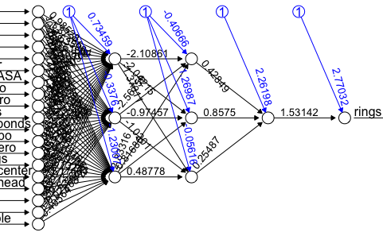

```r
# plot the neural network
plot(nn_src_kin)
```

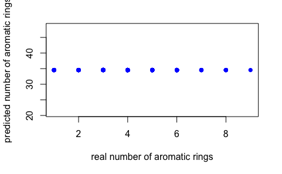

```r
# predict for testing data using the model
predict_testNN = neuralnet::compute(nn_src_kin, testing_df)
predict_testNN = (predict_testNN$net.result * (max(src_kin_2$rings) - min(src_kin_2$rings))) + min(src_kin_2$rings)

# plot the tested versus the predicted
plot(testing_df$rings, predict_testNN, col='blue', pch=16, ylab = "predicted number of aromatic rings", xlab = "real number of aromatic rings")

abline(0,1)
```

```r
# Calculate Root Mean Square Error (RMSE)
RMSE.NN = (sum((testing_df$rings - predict_testNN)^2) / nrow(testing_df)) ^ 0.5
sprintf("RMSE for Neural Network = %f", RMSE.NN)
```

```
[1] "RMSE for Neural Network = 30.403067"
```

#### Analysis of Neural Network Model

As you can see, the neural network model is not good for the prediction of rings based on the data. The error is very high and the RMSE is higher than in the Random Forest, showing us that over-complication of model fitting can lead to misrepresenting the data.

### Conclusions and Further Remarks

SRC Kinase Inhibitors are critical molecules in the space of cancer and act as potential drug inhibitors that can be used for treatment today. Although there are other characteristics that play a huge role in determining the efficacy of these molecules, there are other variables that also play huge roles that are often overlooked sometimes. As this field is so vast, even the smallest contribution can add another piece to the puzzle, continuously improving our research in this field.

In terms of the project, we achieved both of the objectives: the first one being to create a good model that will be an accurate model to predict the number of rings in an SRC Kinase Inhibitor and the second one being to do a comparative analysis of the different models we created and see which performs the best. Out of all the models built, I come to the conclusion that the Random Forest model with 40 trees performs the best on the data compared to all other models built. It accounts for the complexity of the data as well as the variance, causing it to perform well in both training and testing. The MSE plots also give us insight into how well the error decreases as the number of trees increase, showing us that the model performs very well on this dataset. I think the main takeaway from this project would be to really understand how your data is distributed and the variance it contains, utimately using that information to formulate a good predictive model. With the confluence of all the work put in, from initial pre-processing and visual analysis, to model building with numerical and graphical analysis, we ultimately achieved both our goals, leaving us satisfied.

Further steps I would take in this project would be to include a detailed PCA analysis for feature importance as well as being able to figure out a way to include features such as molecular formula or structural characteristics into this dataset. By implementing thes techniques, I think there might be a change in how the data represents the predicted variable and can lead to some new discovery.